# Percepción del Grado de Confianza en la Policía Estatal

*Encuesta Nacional de Seguridad Publica Urbana (ENSU)*

Author

Jesus LM

Published

Jun, 2025

Abstract

En este documento, presentamos los pasos que realizamos para limpiar, unir y consolidad los datos del periodo comprendido entre enero 2015 y marzo 2025.

[figure not shown]

# Metodología

Los datos descargados del [INEGI-ENSU](https://www.inegi.org.mx/programas/ensu/#datos_abiertos) vienen por trimestre. Por ejemplo: (2024-12, 2024-09, 2024-06, 2024-03, etc).

Los campos seleccionados son los siguientes:

- Entidad Federativa (NOM_ENT)
- Municipio (NOM_MUN)
- Sexo (SEXO)
- Edad (EDAD)
- Conf Pol Mun (BP1_9_1)
- Conf Pol Est (BP1_9_2)

## Indicadores

Los campos Conf Pol Mun y Conf Pol Est varian en las diferentes fuentes de datos:

| Perido | Indicadores |
| --- | --- |
| 2025 | (bp1_9_1, bp1_9_2) |
| 2024 | (bp1_9_1, bp1_9_2) |
| 2023 | (bp1_9_1, bp1_9_2) |
| 2022 | (bp1_9_1, bp1_9_2) |
| 2021 | (bp1_9_1, bp1_9_2) |
| 2020 | (bp1_10_1, bp1_10_2) |
| 2020-01 | (bp1_9_1) |
| 2019 | (bp1_9_1, bp1_9_2) |
| 2018 | (bp1_9_1, bp1_9_2) |
| 2017 | (bp1_9_1, bp1_9_2) |
| 2016 | (bp1_8_1, bp1_8_2) |
| 2016-06 | (bp1_7_1, bp1_7_2) |
| 2015 | (p6_1, p6_2) |

## Tabla Consolidada

Por lo tanto, recopilamos los datos con claves de Entidad y Municipio para homologar la carga y consolidación de datos.

Finalmente, la tabla consolidada que comprende el período de enero 2015 a marzo 2025, quedo de la siguiente manera:

Table 1: Tabla Consolidada

| Periodo | Entidad_Federativa | Municipio | Sexo | Edad | Conf_Pol_Mun | Conf_Pol_Est |
| --- | --- | --- | --- | --- | --- | --- |
| 2024-09 | Hidalgo | Cardonal | Hombre | 35 | 2 | 2 |
| 2021-09 | Veracruz de Ignacio de la Llave | Cuitláhuac | Mujer | 68 | - | - |
| 2024-03 | México | Cuautitlán Izcalli | Hombre | 35 | 4 | - |
| 2019-03 | Puebla | Cohetzala | - | - | 4 | 4 |
| 2017-09 | Jalisco | El Limón | - | - | 4 | 3 |

# Resultados

El periodo de estudio comprende desde **enero 2015** hasta **marzo 2025**

La tabla *consolidada* consta de **51,278,059** *registros* y **7** *columnas*.

**40.43%** *de los registros no contienen sexo ni edad*

**26.20%** *de los registros no contienen calificacion sobre las Policias*

Table 2: Tabla con Valores Nulos

shape: (1, 7)

| Periodo u32 | Entidad_Federativa u32 | Municipio u32 | Sexo u32 | Edad u32 | Conf_Pol_Mun u32 | Conf_Pol_Est u32 |
| --- | --- | --- | --- | --- | --- | --- |
| 0 | 0 | 0 | 20733456 | 20733456 | 13435986 | 11915470 |

## Calificacion de Confianza

En la siguiente tabla y grafico se muestran las calificaciones a la Policia Estatal, donde se puede observar que poco mas de la mitad de los encuestados otorgaron una calificacion de 2-3.

Table 3: Distribucion de Calificaciones

| Conf_Pol_Est | Porcentaje |
| --- | --- |
| - | 23.24% |
| 0 | 0.25% |
| 1 | 5.56% |
| 2 | 35.44% |
| 3 | 20.87% |
| 4 | 13.85% |
| 9 | 0.79% |

Figure 1: Distribucion de Calificacion sobre la Policia Estatal

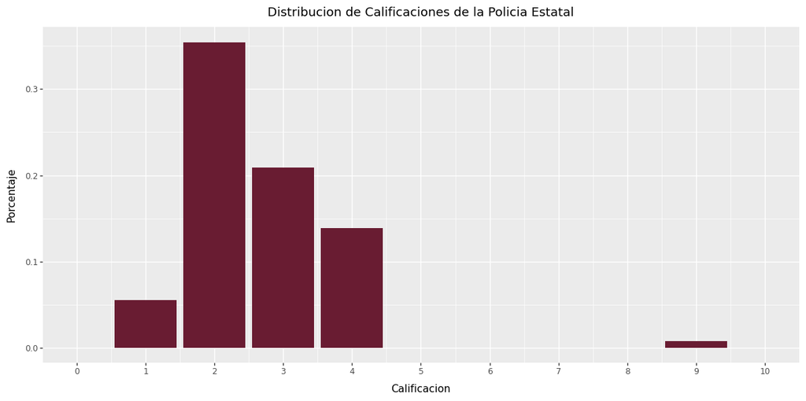

Table 4: Calificacion Promedio por Sexo

| Sexo | Conf_Pol_Est |
| --- | --- |
| Mujer | 2.62 |
| Hombre | 2.64 |
| - | 2.62 |

Figure 2: Distribucion de Calificacion sobre la Policia Estatal por Sexo

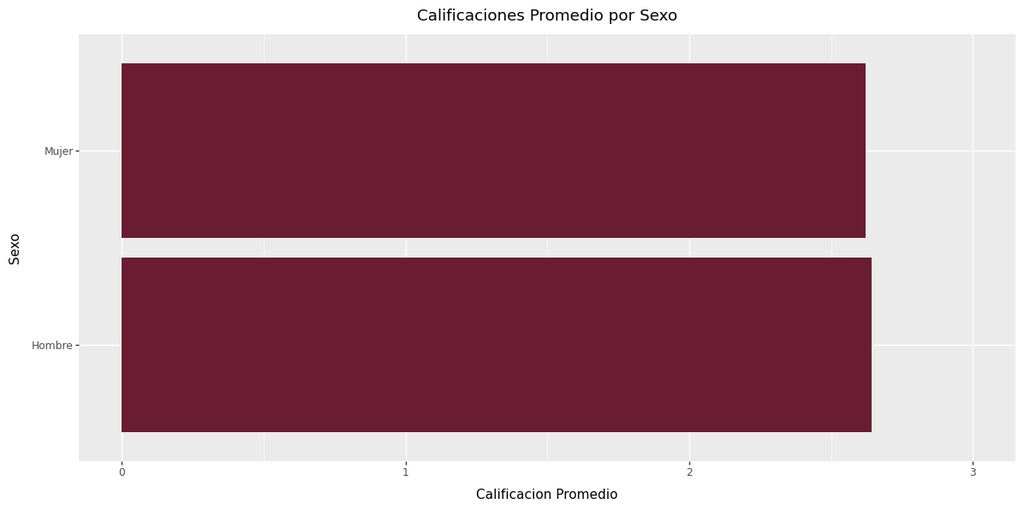

Table 5: Calificacion Promedio por Edad

| Rango_edad | Conf_Pol_Est |
| --- | --- |
| (17, 20] | 2.43 |
| (20, 30] | 2.56 |
| (30, 40] | 2.64 |
| (40, 50] | 2.67 |
| (50, 60] | 2.68 |
| (60, 70] | 2.68 |
| (70, 80] | 2.63 |
| (80, 90] | 2.54 |
| (90, 100] | 2.84 |

Figure 3: Distribucion de Calificacion sobre la Policia Estatal por Rango de Edad

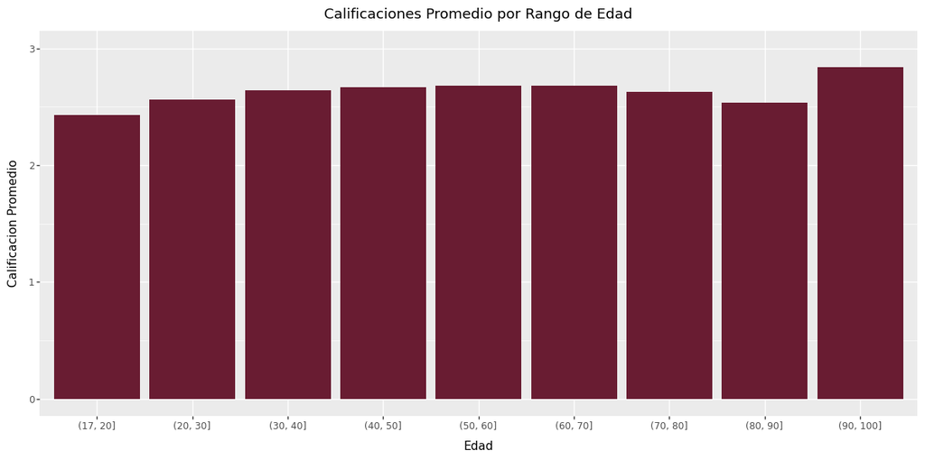

## Grafico de Ranking por Año

(a)

**Nota**

Selecciona la Entidad Federativa para observar el comportamiento temporal en la grafica.

## Grafico de Ranking por Entidad Federativa

(a)

**Nota**

Selecciona el periodo para observar las calificaciones por Entidad Federativa en la grafica.

# Referencias

- INEGI [Encuesta Nacional de Seguridad Pública Urbana (ENSU)](https://www.inegi.org.mx/programas/ensu/#datos_abiertos)
- INEGI [Catálogo Único de Claves de Áreas Geoestadísticas Estatales, Municipales y Localidades](https://www.inegi.org.mx/app/ageeml)

# Contacto

**Jesus Lopez M.**  
*Subdirector de Area*